# Week 1 Notes Part 2 Programming in R

# 1 Arithmetics and Types

## 1.1 Overview

In this section of the Week 1 content, the most basic use of R will be demonstrated and explained informally. We will go over some very simple expressions, learn how to use R interactively as an advanced “calculator”, then discuss data types and special values available in R. This Topic Note is also intended to help students with minimal or no background in software programming to catch up quickly on some basic paradigms. Hence some notions are explained in greater length but less formally than it would be necessary for someone with prior experience in software. Later we will be taking a more in-depth and formal look at various concepts presented here; the main purpose of this Topic Note is to provide some exposure to R and convey the general feel.

## 1.2 Notations

Throughout this course, we are naturally going to encounter a lot of R code, as well as the results of actual code execution. Open R program on your computer and look into your command window. It displays a “>” symbol, referred to as the “prompt”. The prompt indicates that R is idle and waits for user input, or commands to execute. In general, each command in R generates output (some commands choose to explicitly suppress their output, as we will see later). If you type a command at the prompt and press enter, R will immediately proceed to executing the command. If no errors occurred and execution finished successfully, the output of your command will be printed into next line(s) in the command window, right after the input (command) itself.

Throughout these lecture notes, when it is needed to demonstrate the actual R session with inputs (commands) and outputs, we will be using courier font, prefixing actual command (input) with ‘>’ prompt, and using red color for input and blue color for the output. This convention happens to match the default color scheme of the R front end on Windows systems. Note also that symbol “#” indicates start of a comment in R: everything starting from that symbol and through the end of the line is completely ignored by R. We will use this feature often in order to add inline comments to the code snippets – whether you copy just the command itself from these notes, or the full line (command + comment) into your R session, both will execute and produce exactly the same result (try it, and make sure you do not copy the prompt itself!) In other words, when the code snippet looks like:

```r
2 + 2  # comment, ignored by R; command in this line adds 2 and 2
```

```
## [1] 4
```

it means the following: “Type (or copy from the above) 2+2 at the command prompt in your R session. Press enter. R should display 4 as the output of that command”.

## 1.3 Using R as a (graphing) calculator

The example used above represents probably the most basic form of R command: you can type arithmetic expressions (try this!) using numbers and operations (summation, multiplication , subtraction, division, etc), and send them for evaluation by pressing the ‘enter’ key; R will print the results right after each expression. R also provides a collection of built-in mathematical functions (such as, e.g., sine, cosine, logarithm, square root, as well as many more advanced/specialized functions such as special functions, statistical distributions etc). Few examples below (try them or make your own!) illustrate using R as a simple calculator:

```r
72*84
```

```
## [1] 6048
```

```r
(132+498+274)/23 # use parenthesis to specify order of operations
```

```
## [1] 39.30435
```

```r
sqrt(18.5) # square root
```

```
## [1] 4.301163
```

```r
sin(72) # sine. Argument is assumed to be in radians
```

```
## [1] 0.2538234
```

```r
sin(72*pi/180) # sine of 72 degrees (180 degrees equals pi radians)
```

```
## [1] 0.9510565
```

## 1.4 Variables

In R (as in most computer languages), it is possible to hold a result of an expression in a variable- a named placeholder for a value. This feature is indispensable in long, multi-step calculations since it allows storing intermediate results and building up the calculations gradually. In the following snippet, value of 2 is assigned to (or, in other words, stored in) variable x, and value of 3 is assigned to variable y. Assignment in R is traditionally represented as ‘<-‘ (although more conventional ‘=’ is also accepted). Note how ‘x’ or ‘y’ alone represent an expression, with the result being the value stored in the variable:

```r
x <- 2 # store value 2 in variable x
y <- 3 # assign 3 to y
x # value of this expression is the value stored in x
```

```
## [1] 2
```

```r
y
```

```
## [1] 3
```

```r
x+y # adding x and y means adding values stored in them
```

```
## [1] 5
```

```r
x*3
```

```
## [1] 6
```

```r
x <- 4 # we can store new value in the same variable
x*3 # multiplies current value of x by 3 (cf. above)
```

```
## [1] 12
```

```r
# z
# Error: object 'z' not found
z <- (x+y)*2 # can assign any expression, not just a number
z # z is defined now
```

```
## [1] 14
```

A few important things to remember about variables in R:

- Similarly to scripting languages and unlike many modern compiled languages, variables are declared and defined at the time of assignment. It is not required (and in fact not possible) to declare a variable in advance. Note how in the snippet above variables ‘x’ and ‘y’ were defined and made available by assignment, but variable ‘z’ is not available (trying to use it causes an error), since we never assigned anything to it until later in the session. But after we assigned a value to ‘z’, we could use it.
- Variables do not have types (similarly to many scripting languages). However, the values in R do have types, as we will see shortly. If this sounds confusing, consider a “strictly typed” language (such as C/C++, Java, etc), where a programmer is required to announce their intensions explicitly (“I am declaring a variable x that will hold integer values” - a later attempt to assign a text string to x will be illegal and will be caught by the language itself). In dynamically typed languages (such as perl, python - and also R!), values of different types can be (re-)assigned to the same variable, so it is not possible to guarantee that a variable holds, for instance, a number or a text string at any given moment without examining variable’s content (or remembering really well what you assigned to it in your code). Generally, writing code in dynamically typed languages is faster, but debugging can be more difficult (“I was pretty sure my variable ‘y’ was holding a number and I spent few hours trying to find the source of the error until I realized that ‘y’ was in fact holding a list”). When debugging code in R, always look at what your variables actually hold (their values and value types).
- Variable names can contain letters, digits, and dots (‘.’) - the latter is unusual and can be confusing at first if you come from a different language: “my.var” is just a variable name, not an attribute (or method) “var” of an object instance stored in “my”; variable names cannot start with a digit; variable names are case-sensitive: ‘x’, ‘y’, ‘My.var’, z2’ are valid names, ‘2w’ is not.

## 1.5 Sequences and loops

It is easy to generate a range of numbers in R. Let us say we want integers from 1 to 10. Just type:

```r
1:10
```

```
##  [1]  1  2  3  4  5  6  7  8  9 10
```

Sequences or ranges can be useful, for instance, in loops: a basic for loop in R looks as follows:

```r
x <- 1
for ( i in 1:3 ) x+i
```

In the snippet above, we initialize x with value of 1. Then for each value of i in 1, 2, 3 (that’s what the for-loop notation stands for), we re-evaluate the body of the loop. This particular example is not very useful though as the computed value x+i for each value of i is lost: we do not perform any action on it, do not save it etc. To make the example a little bit more meaningful, let us modify the loop body: now we will not only compute x+i, but apply built-in function ‘print’ to it in order to print the value to the screen. Try it and observe the result:

```r
x <- 1
for ( i in 1:3 ) print(x+i)
```

```
## [1] 2
## [1] 3
## [1] 4
```

It is possible to build an arbitrary sequence of values, not just an ordered set of subsequent numbers; a concatenation operation ‘c’ is used for this purpose (note how c() can concatenate either individual values or whole sets of values together):

```r
c(1,5,7,2,19,179) # this is a sequence of individual numbers
```

```
## [1]   1   5   7   2  19 179
```

```r
c(1:5, 19, 3:8) # it is possible to concatenate sequences together
```

```
##  [1]  1  2  3  4  5 19  3  4  5  6  7  8
```

Again, the commands in the snippet above are for demonstration only and are not very useful in practice yet, as the sequences are generated and immediately forgotten (after printing the output value to the screen). But you should be able to realize by now that in practice we could assign such a sequence to a variable, or use it in a ‘for’ loop. Another use is illustrated below.

## 1.6 Plotting

R has very powerful and versatile plotting capabilities: there is a large number of highlyconfigurable built-in plotting functions (even more are available through downloadable packages); for those inclined to coding, R also provides low-level plotting primitives so you can extend R with your own plots, charts, and diagrams. Visualization is indispensable for data analysis, in particular for spotting both trends and irregularities in the data. We will be discussing and extensively using R plotting capabilities throughout this course. Here we show only one simple example in order to illustrate a few concepts. More rigorous definitions and specifications will be given later; for now it is important to develop common-sense understanding. This command will generate a plot shown in the next Figure:

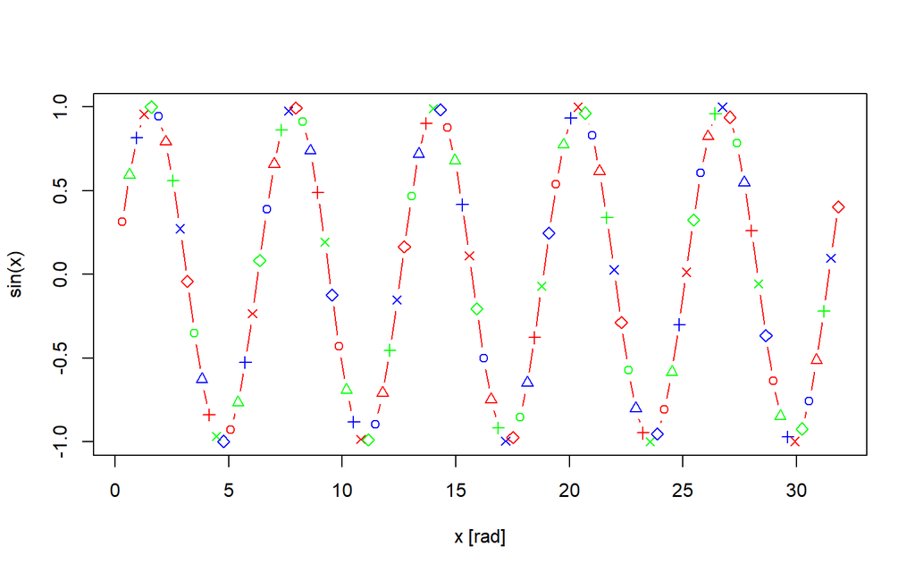

```r
plot(1:100/pi,sin(1:100/pi),type="b",col=c("red","green",
"blue"),pch=1:5, xlab="x [rad]",ylab="sin(x)")
```

In the snippet above, we use a function ‘plot’ (more on functions later in this course). In its basic form, `plot(x,y)`, the function is given two arguments. Each argument is a sequence of numbers. These numbers are paired in succession (i.e. first element of sequence $x$ with first element of sequence $y$, `(x1,y1)`; second element of sequence $x$ with second element of sequence $y$, `(x2, y2)`, etc). Each such pair gives an `x-y` coordinate of a point in a plot. For instance, `plot(1:5,11:15)` would plot 5 points at coordinates (1,11), (2,12),…,(5,15) (you can try it!). Note how in this latter example as well as in the code snippet above we directly generate and pass a sequence of numbers as the argument to the plotting function. The snippet shown is a little more contrived though (we start putting things together!): for the first argument, note how we generate a sequence 1:100 and divide all the numbers in the sequence by `Pi` (‘pi’ is a predefined constant known to R). To better understand the results, you can do a quick experiment in R: type the following into your R session (note that we are using `1:10` here, not `1:100`, just to have smaller output):

```r
1:10/pi
```

```
##  [1] 0.3183099 0.6366198 0.9549297 1.2732395 1.5915494 1.9098593 2.2281692
##  [8] 2.5464791 2.8647890 3.1830989
```

In the example above we ran a quick and simple test in order to better understand what the value of an expression is. R session is interactive. Use it! When not sure, always check what your data look like, what value an expression returns (you may be surprised how far it can be from what you expected), etc.

Let us now take a look at the second argument of the plot function in the plotting code we started this section with. We already know what ‘$1:100/pi$’ is, but now this sequence of numbers is passed to the function sin(). This function can take a sequence of numbers as its input, and returns a sequence of the same length, with each element equal to the sine of the corresponding element of the input sequence. Now it becomes clear that `plot()` in our example is going to draw a plot of sine function: we pass a sequence of x values and a sequence of corresponding `sin(x)` values as the `(x,y)` coordinates of the points in the plot.

Additional arguments in our example are optional and control fine details of the resulting plot (most built-in R functions have optional arguments, and it is likely the functions you write will eventually have them to). Plot() will work without all those additional arguments but the resulting drawing will not be as pretty (try it!). With those additional arguments shown in the example, we tell the `plot()` function to

- plot both the specified (x,y) points (our data points) and connecting lines between them (`type=’b’`, where ‘b’ stands for “both”, i.e. “points and lines”). We could plot only data points (type=’p’ for ‘point’) or only connecting lines (`type=’l’` for ‘lines’) - try it!
- rotate and recycle red, green, and blue colors for subsequent data points in the plot (`col=c(‘red’,’green’,’blue’)` – do you recognize concatenation operator `c()`, i.e. the color argument is a sequence in this example?)
- rotate and recycle symbol used to plot subsequent data points (`pch=1:5`, different symbols – triangles, circles, squares, etc have different numerical codes)
- Draw meaningful axis labels (`xlab=...`, `ylab=...`) If the syntax of passing arguments to a function looks strange to you, just accept it for now. In R we can pass (argument_name=argument_value) pairs to any function (those who know python may find this familiar), and this will be discussed in more detail soon.

We will be seeing many examples of using the plot() function (and many others), the important take home message from this example is that (1) functions take arguments; and (2) there can be many (often times optional) arguments that can be used to control and fine-tune the behavior of a given function. It is unlikely you will ever remember all the possible arguments of all the available commands (functions). Eventually, you will remember a few most important/most used ones, for a handful of functions you use the most; you will be using documentation every time you need to look up more obscure and esoteric arguments or arguments for functions you rarely use. So after working through this example, take a look at the help page of the plot command (type `?plot` at the R prompt) and see how many additional optional arguments it can take to fine-tune the resulting plot.

### 1.6.1 ggplot2: a more powerful alternative

`plot()` and R’s other base graphics functions are good for a quick, exploratory look at your data, but `ggplot2`, a widely used add-on package, is usually the faster route to a polished, publication-quality figure, and it is what we will use for most figures for the remainder of this course, including in this week’s homework. Rather than plotting `x` and `y` directly, `ggplot2` builds a plot out of three pieces: a dataset, an aesthetic mapping (`aes()`, which columns of that dataset control which visual properties, position, color, size, and so on), and one or more geometric layers (`geom_point()`, `geom_line()`, `geom_histogram()`, etc.) describing how the mapped data should actually be drawn. Layers are combined with `+` rather than passed as arguments to a single function call.

We do not have data frames yet formally (that is covered later, in the Data Structures Topic Note), but `data.frame()` is simple enough to use here without getting ahead of ourselves: it just bundles named vectors of equal length into a single table-like object, which is the format `ggplot2` expects. Here is the same sine curve from the `plot()` example above, this time built with `ggplot2`, so you can compare the two directly:

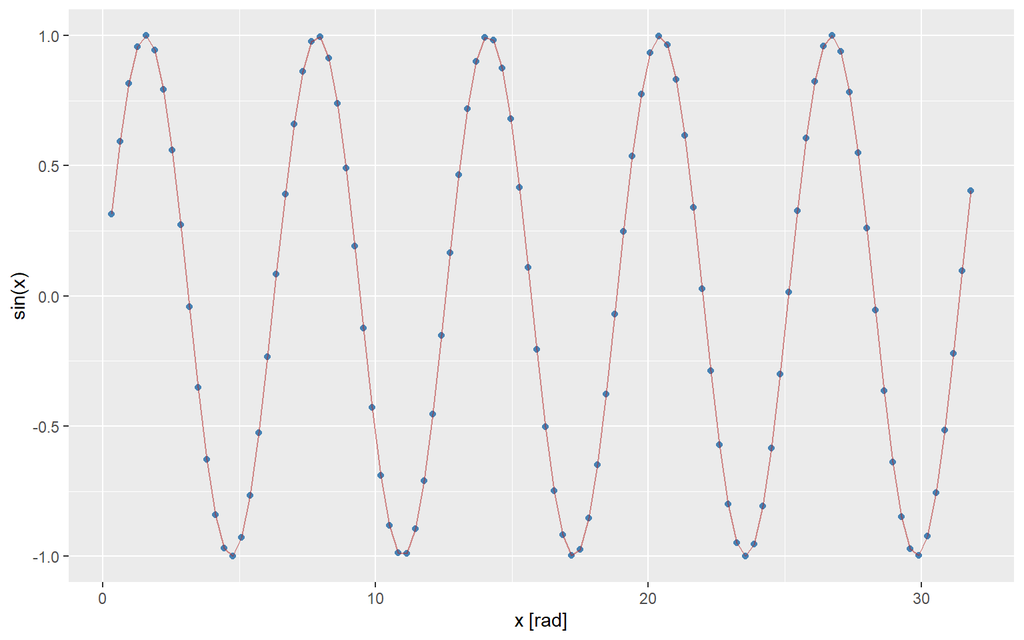

```r
library(ggplot2)
df <- data.frame(x = 1:100/pi, y = sin(1:100/pi))
ggplot(df, aes(x = x, y = y)) +
  geom_point(color = "steelblue") +
  geom_line(color = "firebrick", alpha = 0.5) +
  labs(x = "x [rad]", y = "sin(x)")
```

`ggplot(df, aes(x = x, y = y))` sets up the plot against the data in `df` and states that column `x` controls horizontal position and column `y` controls vertical position; nothing is actually drawn until a `geom` layer is added. `geom_point()` draws the points, `geom_line()` connects them, and `labs()` sets the axis labels, each one added with `+` on its own line, which is the conventional way to keep a multi-layer `ggplot2` call readable.

Where `ggplot2` really earns its keep is mapping a variable in your data to a visual property automatically, rather than specifying one fixed color for everything. Using the built-in `iris` dataset:

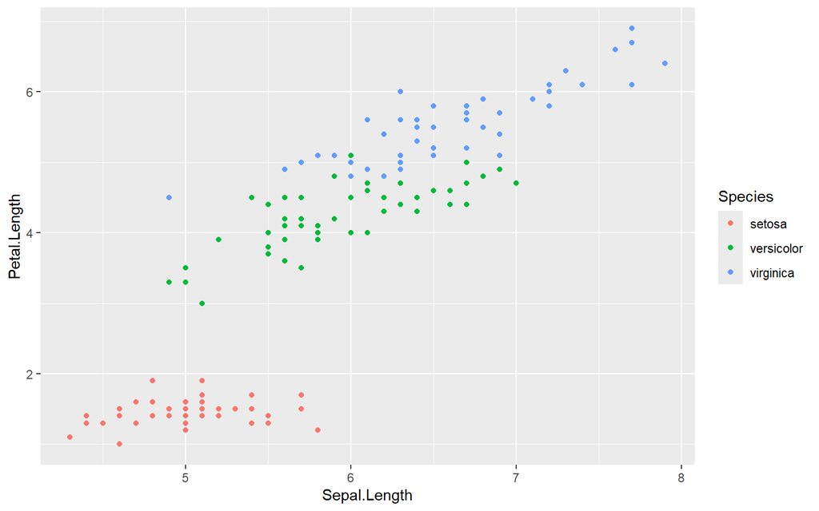

```r
data(iris)
ggplot(iris, aes(x = Sepal.Length, y = Petal.Length, color = Species)) +
  geom_point()
```

Placing `color = Species` inside `aes()` tells `ggplot2` to color every point according to that observation’s `Species` value and to generate a matching legend automatically; nothing had to be colored by hand. This is exactly the pattern you will use later this week to color a volcano plot’s points by significance, and it is a big part of why `ggplot2` scales better than base graphics once you are visualizing more than one or two dimensions of your data at a time.

## 1.7 R data types

We mentioned already that in R the variables do not have predefined types but the data (values) do. ‘mode’ is a useful command that returns the type of the data value:

```r
mode(1)
```

```
## [1] "numeric"
```

```r
mode("abc")
```

```
## [1] "character"
```

```r
mode(TRUE)
```

```
## [1] "logical"
```

```r
mode(7+5i)
```

```
## [1] "complex"
```

```r
x<-5.5
mode(x)
```

```
## [1] "numeric"
```

```r
x<-"text"
mode(x)
```

```
## [1] "character"
```

As the examples above imply, there are a few basic data types:

- Numeric : this is what we refer to as a number and can add, multiply, compute square root of, etc. NOTE: R is aware of integer and floating point numbers (distinct types in most other languages!), but for R they are only “storage modes”, not really distinct types. At high level, R switches between them seamlessly and there is no way to stay within integer arithmetic, for instance: 1/3 is 0.3333, not 0, unless you explicitly round the result.
- Character: any text string. You can create a text string in R by surrounding any string of symbols by either single or double quotation marks. There is no difference between the two types of quotations: “my string” and ‘my string’ represent the same value of character type. NOTE that what is called ‘character’ in R is usually called a “character string” or simply a “string” in other languages – text, string of symbols. In contrast to other languages, R does not have a separate type that represents a single symbol (‘character’ type in other languages). “a”, “b” and “ab” all have the same type ‘character’ in R. Always remember that character value in R is enclosed in single set of quotation marks, while a sequence of character values is a different thing altogether: “abcd” is a single character value, while `c("a", "b", "cd")` is a sequence (or “vector” as we will learn soon) of three separate character values (or text strings): “a”, “b” and “cd”.
- Logical: a special type that can have only two values, true or false. In R these values are represented by `TRUE` and `FALSE`, as well as by shorthand versions `T` and `F`. These keywords (`TRUE`, `FALSE`, `T`, `F`) are recognized by the R interpreter and you can type them directly into your expressions. Do not use quotation marks! `TRUE` is a special word recognized by R. `TRUE` is a text string (a value of character type) that has no special meaning to R. Logical values are most often the result of logical operations (e.g. comparison `5 < 10` returns `TRUE`: 5 is indeed less than 10), but in some situations you may find it useful, for instance, to manually initialize a sequence of logical values for specific usage.
- Complex: complex numbers.

The use of `mode()` function on a variable is illustrated in the last few lines of the snippet above. When applied to a variable, this function returns the mode (type) of the value that variable currently stores. For instance, mode(x) was numeric after we assigned 5.5. to $x$ (i.e. $x$ holds numeric value). But after we assigned string (character) value “text” to the same variable $x$, `mode(x)` promptly returned character, in accordance with the variable’s current content.

Note that in this introductory course we are taking a practical and limited view of R. We will be discussing its most important and widely used features and leave some more esoteric ones completely out of the scope. In particular, the actual language paradigm is different from most traditional languages (although this is going to be completely transparent to us in this course): everything in R is an object that can be programmatically manipulated and modified (this is one reason why variables cannot have pre-defined/pre-declared types: the variable name (symbol) is an object itself!). Hence, there are more types in the language, although they are not going to be important to us. Recall the `plot()` function we briefly inspected in the previous section. Try typing command `mode(plot)` in R – the result is ‘function’. This is one of (many) additional types, and the behavior we just observed illustrates the fact that functions in R are simply objects with their own type, so they can be assigned and manipulated just like any other object.

R also provides some (relatively limited) support for Object Oriented Programming. ‘class’ is another useful function that allows examining object structure. For simple atomic objects that do not have “true” class, as in the examples above, class() will be the same as mode(). In R, object’s class can be assigned (we are not going to use this feature in this course!).

## 1.8 R special values

R provides a few special values that can be a result (output) of some expression or function, or can be used explicitly in the R commands, just like any other predefined constant value. These special values include:

- `Inf`, `Inf`: represent an infinite result (strictly speaking, a result that is too large for R to compute, overflow). Try raising 3 to the power 1000 or dividing something by zero:

```r
3^1000
```

```
## [1] Inf
```

```r
-3^1000
```

```
## [1] -Inf
```

```r
1/0
```

```
## [1] Inf
```

- `NaN` – not a number. Used when result makes no sense. For instance, as in the example below, subtracting two numbers, both of which are too large for R to compute/represent is undefined: the actual result could be 100, 0, or -18.5, but R has no way of knowing. Note that “Inf” is not just a way R uses to tell us that the result was infinite (by printing it into the output), it is an actual special value that we can type into any expression (as in the first line in the example below) or even assign to a variable. The second input line below illustrates a very common caveat in numerical computations: we ask R to compute two very large numbers (since power takes precedence over subtraction, R will first try to compute both operands and then subtract one from the other). The operands are so large, however, that they cause overflow and each becomes an `Inf`, so when R proceeds to subtracting them, it comes up with a `NaN`: it is clear to a human that the result is 0, but since both operands are already `Inf` for R, it does not know how to subtract them anymore. Smart reordering of numerical operations in your code goes long way towards eliminating this and similar types of overflow or loss-of-precision numerical errors.

```r
Inf - Inf # note that we can type Inf as a “value” in a command
```

```
## [1] NaN
```

```r
3^1000 - 3^1000 # same thing. Subtracting Inf from Inf
```

```
## [1] NaN
```

```r
0/0
```

```
## [1] NaN
```

- `NULL` – a special value that represents “nothing”, “empty value”
- `NA` – “not available”, usually used to represents a missing value in the data (e.g. missing/failed experimental measurement in a series of measurement).

`NA` is by far the most common special value we are going to be dealing with when working with real data, and it is important to make a few notes about this value.

`NA` is neither 0, nor “” (empty string), nor `FALSE`, nor `NULL`. It is a separate value that has its own evaluation rules. Consider the following examples:

```r
NA==1 # logical expression: is NA (missing value) equal to 1?
```

```
## [1] NA
```

```r
1+NA
```

```
## [1] NA
```

```r
max(c(NA, 4, 7)) # max() takes a sequence and returns maximum element
```

```
## [1] NA
```

```r
max(c(NA, 4, 7), na.rm=T) # use additional optional argument to max
```

```
## [1] 7
```

```r
NA | TRUE
```

```
## [1] TRUE
```

```r
NA & TRUE
```

```
## [1] NA
```

```r
sort(c(5,3,NA,7)) # sort() takes a sequence and sorts it
```

```
## [1] 3 5 7
```

```r
sort(c(5,3,NA,7),na.last=T) # ask sort() to keep NA, not discard them
```

```
## [1]  3  5  7 NA
```

Note how in the first command in the snippet above we are trying to compare missing value (`NA`) to a number (specifically, we ask if they are equal). The result of such comparison is missing as well (`NA` is returned) - we cannot possibly tell whether a missing value is equal or not equal to 1! In the next command, adding missing value to 1 gives rise, quite intuitively, to a missing value in the result: if we do not know the result of some measurement, we also do not know what that result incremented by 1 is going to be. Attempt to compute a maximum among a set of values that contain a missing value by default also returns `NA` (what if the missing value was the largest - but we missed it, so strictly speaking we do not know what maximum is!). If we want to compute the maximum of the remaining values, we should explicitly instruct the `max()` function to discard missing values and use the rest by providing additional (optional) argument, as shown in the example above. Logical OR between `NA` and something that is `TRUE` is `TRUE` (because OR is `TRUE` when at least one operand is `TRUE`, so the missing value is irrelevant here). But logical AND between `NA` and `TRUE` is `NA` (because AND is `TRUE` only when both operands are `TRUE`, and since one of them is missing the result of AND operation is missing too).

Finally, note how `sort()` deals with `NA` in a way very different from `max()`: by default it discards `NA`! In contrast to `max()`, it makes some sense in this particular case (we do not know where missing value should be placed in the sorted sequence, but wherever it is, the order of the remaining values is the same, so it always makes sense to sort them). However in general you should always check documentation to learn how a particular function deals with NA: even the base package (vast collection of functions that come installed with R by default) can have some subtle inconsistencies, with some functions discarding `NA` by default and others returning `NA`.

### 1.8.1 Checking for special values

How do we check that a value (result of evaluation of an expression/function, or a value in the dataset we are trying to analyze) is one of the special values? `NA` is a recognized value in R that can be typed into a command. However comparing `NA` to `NA` directly does not help much (see below). Instead, R provides special query functions. These functions return logical values `TRUE` or `FALSE` depending on whether the value they are testing is special:

```r
NA == NA # no, comparing NA to NA directly does not help
```

```
## [1] NA
```

```r
is.na(NA) # this is how we check if an object is NA!!
```

```
## [1] TRUE
```

```r
is.null(NULL) # check if the object/value is NULL
```

```
## [1] TRUE
```

```r
is.nan(NaN) # check if the object/value is NaN
```

```
## [1] TRUE
```

```r
is.infinite(Inf)
```

```
## [1] TRUE
```

It is important to understand the first command in the example above: we are asking if the two missing (i.e. unknown) values are equal, so the result is missing (unknown) as well! In the next command we are instead asking R explicitly, if a particular value is missing. The answer to that question is definitely yes (TRUE).